# Supplementary Figure 1 - WT projection, RIG-I-only signature characterization and benchmarking

Carlos Ramirez

2026-10-27 17:08:45

This markdown reproduces the panels of **Supplementary Figure 1**, which supports the definition of the RIG-I-only signature (Figure 1):

Panels:

| Panel | File (`figures/supplementary_figure_01/`) | Original script / original PDF |
| --- | --- | --- |
| WT samples projected onto the concatenated PCA | `pca_concatenated_projection_wt.pdf` | `july_2026/01_rigi_stat_only_signatures_definition.Rmd` (chunks `extracting_wt` / `projecting_WT`); `figures/2026_May/` |
| scRNA-Seq heatmap of the RIG-I-only genes (with IFN genes) | `heatmap_rigi_only_signature_with_IFNs.pdf` | `july_2026/01_rigi_vs_stat_signatures.Rmd`; `figures/2026_August/` |
| RIG-I-only vs NF-κB / viral GO scores (scatter) | `rigi_vs_nfkb_virusgo.pdf` | `july_2026/01_rigi_vs_stat_signatures.Rmd`; `figures/2026_August/` |
| ROC: dsRNA 3h vs dsRNA 16h (no IFN priming) | `roc_curves_rigi_vs_nfkb_viral_go_test.pdf` | `july_2026/01_rigi_vs_stat_signatures.Rmd`; `figures/2026_August/` |
| ROC: all dsRNA vs all polyC cells | `roc_curves_rigi_vs_nfkb.pdf` | earlier version of `july_2026/01_rigi_vs_stat_signatures.Rmd` (see below); `figures/2026_August/` |
| Enrichr results, general repositories | `scatterplot_rigi_gsea_general.pdf` | `july_2026/01_rev_00_signature_similarity.Rmd`; `figures/2026_August/` |

(Original scripts are in `/media/ag-cherrmann/cramirez/interferon_model/scripts/R/`, original PDFs in `/media/ag-cherrmann/cramirez/interferon_model/figures/`.)

## Which RIG-I-only signature is used in each panel

Two versions of the RIG-I-only signature exist and **both are used in this figure**, exactly as in the original panels:

- **Final signature** (`path2signs`, written by `figure_01.Rmd`; identical to `/media/ag-cherrmann/cramirez/interferon_model/analysis/2026_May/rigi_vs_stat_only_signatures.rds`): concatenated PCA of the IFN + **RIG-I KO** bulk samples, top-100 PC1 genes, IFN genes and OASL removed (94 RIG-I-only genes, 99 STAT-only genes). Used by `scatterplot_rigi_gsea_general.pdf`.
- **“All-samples” signature with IFN genes**: computed in `01_rigi_vs_stat_signatures.Rmd` (re-computed below, section RIG-I-only signature with IFN genes). Same Aleksandr gene sets and same procedure, but the concatenated PCA uses the IFN samples plus **all** dsRNA time-course samples (WT **and** RIG-I KO) and the IFN genes are **not** removed (100 genes; it contains IFNB1, IFNL1-4). The original script saved it as `/media/ag-cherrmann/cramirez/interferon_model/analysis/2026_August/rigi_vs_stat_signatures.rds` (2026-09-24, i.e. when the PDFs were produced); we check below that our re-computation is identical. 87/100 genes are shared with the final RIG-I-only signature (differences: IFNL1, IFNL3, IFNL2, IFNB1, IFNL4, IFNL3P1, CXCL3, PLA2G4C, PRR15, TTC9B, NR2F1, PTGER4, GABARAPL1 only in the all-samples version; SHISA7, GAD1, AL353743.4, HES1, ZNF331, NCOA7, ELMSAN1 only in the final version). Used by `heatmap_rigi_only_signature_with_IFNs.pdf` (hence “with_IFNs”), `rigi_vs_nfkb_virusgo.pdf`, `roc_curves_rigi_vs_nfkb_viral_go_test.pdf` and `roc_curves_rigi_vs_nfkb.pdf`.

The WT projection panel does not use a signature; it uses the concatenated PCA of Figure 1 (`analysis/figure_01/pca_concatenated.rds`).

# Input data

[output not shown]

Gene sets not needed for these panels (the Schoggins ISG list and GOBP_RIG_I_SIGNALING_PATHWAY, used only in a fgsea check of the original script) are not loaded.

```r
library(ggplot2)
library(dplyr)
library(readr)
library(ggrepel)
library(scales)
library(patchwork)
library(Seurat)
library(pROC)
library(enrichR)

source('/media/bq-storage/ag-cherrmann/cramirez/decoupling_rigi_ifn/scripts/R/settings.R')
```

## Initial settings

```r
dirs <- section_dirs("supplementary_figure_01")
path2figures <- dirs$figures
path2analysis <- dirs$analysis

knitr::opts_chunk$set(
  message = FALSE,
  warning = FALSE,
  error = FALSE
)
```

# Loading the bulk RNA-Seq data

## IFN treated samples

Bulk RNA-Seq of A549 cells treated with IFN-β at different time points (VST values). The `dsRNA-16h` sample is removed, as in the original analysis.

```r
ifn_df <- read_tsv(file.path(path2project,
                             'analysis/01_QC_visualization/vst_interferon_RNASeq.tsv.gz'),
                   show_col_types = FALSE) %>%
                as.data.frame()
colnames(ifn_df) <- gsub('raw_counts_', '', colnames(ifn_df))

## Removing dsRNA 16 hours
ifn_df <- ifn_df[, colnames(ifn_df) != 'dsRNA-16h']

ifn_ensembl_ids <- ifn_df$ensemb_id
ifn_mtx <- dplyr::select(ifn_df, -ensemb_id) %>%
                as.matrix()
rownames(ifn_mtx) <- ifn_ensembl_ids

dim(ifn_mtx)
```

```
## [1] 60623    19
```

```r
colnames(ifn_mtx)
```

```
##  [1] "control-12h"  "control-16h"  "control-24h"  "control-2h"   "control-48h"
##  [6] "control-4h"   "control-6h"   "control-72h"  "control-8h"   "control-8h-a"
## [11] "IFN-12h"      "IFN-16h"      "IFN-24h"      "IFN-2h"       "IFN-48h"
## [16] "IFN-4h"       "IFN-6h"       "IFN-72h"      "IFN-8h"
```

## dsRNA electroporated (EPO) samples

Bulk RNA-Seq of A549 WT and RIG-I KO cells electroporated with dsRNA / polyC or mock (VST values). The `gene_name` / `ensembl_id` columns are used as gene annotation.

```r
epo_gex <- readr::read_tsv(
        "/media/ag-cherrmann/cramirez/rnaSeq_dsRNA/analysis/sept_2025/01_exploratory_data_analysis/vst_dsRNA_sept2025.tsv.gz",
        show_col_types = FALSE) %>%
              as.data.frame()

colnames(epo_gex) <- gsub('raw_counts_|_featureCounts.tsv',
                      '', colnames(epo_gex))

gene_anns <- dplyr::select(epo_gex, gene_name, ensembl_id)

rownames(epo_gex) <- epo_gex$ensembl_id
colnames(epo_gex)
```

```
##  [1] "KO_control-16h" "KO_control-2h"  "KO_control-48h" "KO_dsRNA-12h"
##  [5] "KO_dsRNA-16h"   "KO_dsRNA-24h"   "KO_dsRNA-2h"    "KO_dsRNA-48h"
##  [9] "KO_dsRNA-4h"    "KO_dsRNA-6h"    "KO_dsRNA-72h"   "KO_dsRNA-8h"
## [13] "KO_polyC-12h"   "KO_polyC-16h"   "KO_polyC-24h"   "KO_polyC-2h"
## [17] "KO_polyC-48h"   "KO_polyC-4h"    "KO_polyC-6h"    "KO_polyC-72h"
## [21] "KO_polyC-8h"    "WT_control-16h" "WT_control-2h"  "WT_control-48h"
## [25] "WT_dsRNA-12h"   "WT_dsRNA-16h"   "WT_dsRNA-24h"   "WT_dsRNA-2h"
## [29] "WT_dsRNA-48h"   "WT_dsRNA-4h"    "WT_dsRNA-6h"    "WT_dsRNA-72h"
## [33] "WT_dsRNA-8h"    "WT_polyC-12h"   "WT_polyC-16h"   "WT_polyC-24h"
## [37] "WT_polyC-2h"    "WT_polyC-48h"   "WT_polyC-4h"    "WT_polyC-6h"
## [41] "WT_polyC-72h"   "WT_polyC-8h"    "gene_name"      "ensembl_id"
```

# WT projection onto the concatenated PCA

**Panel `pca_concatenated_projection_wt.pdf`.** The concatenated PCA of the IFN and RIG-I KO samples is defined in Figure 1 (`figure_01.Rmd`) and loaded here. The VST values of the IFN, RIG-I KO and WT samples (restricted to the genes used in the PCA) are projected with `predict()`; the IFN and KO samples are drawn in grey and the WT samples in red.

```r
pca_list <- readRDS(file.path(path2repo, 'analysis/figure_01/pca_concatenated.rds'))
pca_concatenated <- pca_list$pca
intersected_genes <- pca_list$intersected_genes
pc1_var <- pca_list$pc1_var
pc2_var <- pca_list$pc2_var

length(intersected_genes)
```

```
## [1] 1221
```

```r
c(pc1_var, pc2_var)
```

```
## [1] 49.2 28.4
```

```r
## RIG-I KO samples (as in the PCA of Figure 1)
epo_mtx_subset <- epo_gex[, grepl('KO', colnames(epo_gex))]

## IFN samples
ifn_mtx_subset <- ifn_mtx

## WT samples
wt_gex <- epo_gex[,grepl('WT|gene_name|ensembl_id',
                          colnames(epo_gex))]
wt_mtx <- wt_gex
rownames(wt_mtx) <- rownames(wt_gex)
wt_mtx <- select(wt_mtx, -gene_name, -ensembl_id) %>%
                as.matrix()

concatenated_wt_mtx <- cbind(ifn_mtx_subset[intersected_genes,],
                             epo_mtx_subset[intersected_genes,],
                             wt_mtx[intersected_genes,])
dim(concatenated_wt_mtx)
```

```
## [1] 1221   61
```

```r
projected_wt <- predict(object = pca_concatenated,
                        newdata = t(concatenated_wt_mtx))
projected_wt_df <- as.data.frame(projected_wt)
rn <- rownames(projected_wt_df)
projected_wt_df$batch <- ifelse(
  grepl("^(control|IFN)", rn), "IFN",
  ifelse(
    grepl("^KO", rn), "KO",
    ifelse(grepl("^WT", rn), "WT", NA)
  )
)
projected_wt_df$treatment <- sub(".*(control|IFN).*", "\\1", rn)
projected_wt_df$genotype  <- sub(".*(KO|WT).*", "\\1", rn)
```

```r
projected_wt_df$treatment <- gsub("_.*", "", projected_wt_df$treatment)
projected_wt_df$time <- gsub(".*-", "", rownames(projected_wt_df))
projected_wt_df$time <- gsub("h", "", projected_wt_df$time)
projected_wt_df$"sample" <- rownames(projected_wt_df)
projected_wt_df <- mutate(projected_wt_df,
                          condition = dplyr::case_when(
                        stringr::str_detect(sample, "control") ~ "control",
                        stringr::str_detect(sample, "IFN")     ~ "IFN",
                        stringr::str_detect(sample, "polyC")   ~ "polyC",
                        stringr::str_detect(sample, "dsRNA")   ~ "dsRNA",
                        TRUE ~ NA_character_
    ))

projection_wt <- projected_wt_df %>%
  ggplot(aes(
    PC1, PC2,
    colour = batch,
    shape = condition,
    label  = time
  )) +
  geom_point(size=4) +
  geom_text_repel(size = 6) +

  ## custom colors
  scale_colour_manual(
    values = c(WT = "red", KO = "gray80", IFN = "gray80")
  ) +

  ## exactly three breaks on each axis
  scale_x_continuous(breaks = scales::pretty_breaks(n = 3)) +
  scale_y_continuous(breaks = scales::pretty_breaks(n = 3)) +

  ## axis labels with explained variance
  labs(
    x = paste0("PC1 (", pc1_var, "% variance)"),
    y = paste0("PC2 (", pc2_var, "% variance)")
  ) +

  ## bigger axis text
  theme_classic() +
  theme(
    axis.text  = element_text(size = 16),
    axis.title = element_text(size = 18)
  )


pdf(file.path(path2figures, 'pca_concatenated_projection_wt.pdf'),
    width=6, height=5)
projection_wt
dev.off()
```

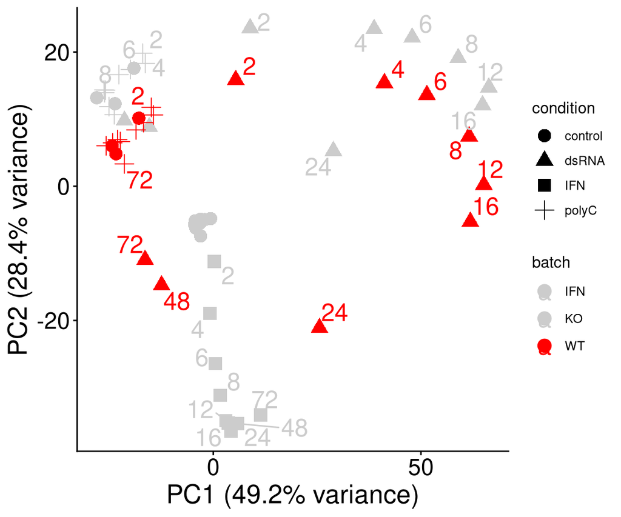

```r
projection_wt
```

# RIG-I-only signature with IFN genes

The single-cell panels were produced by `01_rigi_vs_stat_signatures.Rmd`, which defines its own RIG-I-only signature (see Which RIG-I-only signature is used in each panel). We re-compute it here: genes dynamic in the IFN time course (`ifn_set`) or in the RIG-I KO dsRNA time course (`ko_set`) are loaded, the shared genes removed, and a PCA of the IFN samples plus **all** dsRNA time-course samples (WT and KO) is computed. The RIG-I-only signature is the top-100 genes (gene symbols) of the PC1 loadings.

```r
ifn_set <- readRDS('/media/ag-cherrmann/cramirez/interferon_model/data/aleksandr_genes/IFNb_Response_Omnibus_Strict_FCcorresp.rds')
length(ifn_set)
```

```
## [1] 196
```

```r
dsRNA_set <- readRDS('/media/ag-cherrmann/cramirez/interferon_model/data/aleksandr_genes/wt_ko_splines_gene_sets.rds')
ko_set <- dsRNA_set$ko
length(ko_set)
```

```
## [1] 1183
```

```r
# Genes only in IFN set
ifn_only <- setdiff(ifn_set, ko_set)

# Genes only in KO (RIG-I KO) set
rigi_only <- setdiff(ko_set, ifn_set)
```

```r
## no shared genes
concatenated_genes <- unique(c(ifn_only, rigi_only))
selected_genes <- concatenated_genes

## preparing epo mtx (all WT and KO samples)
epo_all_mtx_subset <- dplyr::select(epo_gex, -gene_name, -ensembl_id)
epo_all_mtx_subset <- epo_all_mtx_subset[selected_genes, ]

## preparing ifn mtx
ifn_all_mtx_subset <- ifn_mtx[selected_genes, ]

## getting intersection
intersected_genes_all <- intersect(rownames(ifn_all_mtx_subset),
                                   rownames(epo_all_mtx_subset))

concatenated_mtx <- cbind(ifn_all_mtx_subset[intersected_genes_all,],
                          epo_all_mtx_subset[intersected_genes_all,])

pca_all <- prcomp(t(concatenated_mtx),
                  center = TRUE,
                  scale. = FALSE,
                  retx = TRUE,
                  rank. = 10)
```

Genes are ranked by their PC1 / PC2 loadings after converting Ensembl IDs to gene symbols.

```r
pc1 <- pca_all$rotation %>%
        as.data.frame() %>%
               dplyr::arrange(desc(PC1)) %>%
                select(PC1)

pc2 <- pca_all$rotation %>%
        as.data.frame() %>%
               dplyr::arrange(desc(PC2)) %>%
                select(PC2)

pc_signatures <- list(pc1=pc1,
                      pc2=pc2)

## ensemblid to gene symbol
pc_signatures_gs <- lapply(pc_signatures,
                           function(genes_df){
                                   gene_names <- plyr::mapvalues(
                                           x = rownames(genes_df),
                                           from = gene_anns$ensembl_id,
                                           to = gene_anns$gene_name,
                                           warn_missing = FALSE
                                   )
                                   genes_df$'gene_symbol' <- gene_names
                                   genes_df$'ensembl_id' <- rownames(genes_df)
                                   genes_df <- genes_df[!duplicated(genes_df$gene_symbol),]
                                   rownames(genes_df) <- genes_df$gene_symbol
                                   genes_df
                           })

pc_ranks <- lapply(pc_signatures_gs, function(df) {
  v <- df[[1]]
  names(v) <- rownames(df)
  sort(v, decreasing = TRUE)
})

rigi_only <- pc_ranks$pc1 %>%
                   head(100) %>%
                   names

stat_only <- pc_ranks$pc2 %>%
                   tail(100) %>%
                   names

saveRDS(list(stat_only=stat_only,
             rigi_only=rigi_only),
        file = file.path(path2analysis, "rigi_vs_stat_signatures_all_samples_with_IFNs.rds"))

signatures_gene_symbol <- list(rigi_only=rigi_only,
                               stat_only=stat_only)
rigi_only
```

```
##   [1] "IFNL1"      "IFNL3"      "IFNL2"      "EGR4"       "IFNB1"
##   [6] "CXCL11"     "FOSB"       "IFNL4"      "CXCL10"     "IL6"
##  [11] "EGR2"       "CH25H"      "LRRN3"      "NR4A3"      "CXCL8"
##  [16] "TNFAIP3"    "EGR3"       "FOS"        "RAET1L"     "PPP1R15A"
##  [21] "RND1"       "CCL4"       "OTUD1"      "PTGS2"      "CYP1A1"
##  [26] "SLC1A3"     "NOCT"       "PMAIP1"     "DDIT3"      "IFNL3P1"
##  [31] "C2CD4A"     "HIP1R"      "NEURL3"     "SNPH"       "C11orf96"
##  [36] "ATP4A"      "RTL9"       "KLF4"       "CSRNP1"     "CITED2"
##  [41] "ZC3HAV1"    "PER1"       "CLEC17A"    "SEMA3D"     "HIF1A-AS3"
##  [46] "DCHS1"      "RANBP3L"    "BBC3"       "MAFF"       "SCN3A"
##  [51] "ACTN2"      "TSPYL2"     "SLC8A2"     "IL1A"       "TCHH"
##  [56] "KRT17"      "ACAN"       "AC018398.1" "ARL5B"      "RHCG"
##  [61] "PRDM1"      "EFNA1"      "MXD1"       "ZEB2"       "KDM6B"
##  [66] "HSD17B7P2"  "JUN"        "CREB5"      "SLC12A7"    "COL5A3"
##  [71] "ICAM1"      "CCL20"      "CREBRF"     "PPP4R4"     "TRAF1"
##  [76] "USP43"      "FZD4"       "RHEBL1"     "AL606500.1" "DUSP8"
##  [81] "AC099489.1" "KLK10"      "SNAPC1"     "CXCL1"      "SLCO5A1"
##  [86] "CXCL3"      "TRIM26"     "PLA2G4C"    "CCNL1"      "ZFP36"
##  [91] "KLF2"       "KLF6"       "PRR15"      "HIVEP2"     "NFIL3"
##  [96] "TTC9B"      "NR2F1"      "GATA6"      "PTGER4"     "GABARAPL1"
```

Check: the re-computed signature is identical to the one saved by the original script when the PDFs were produced, and comparison with the final RIG-I-only signature (`path2signs`).

```r
original_signs <- readRDS('/media/ag-cherrmann/cramirez/interferon_model/analysis/2026_August/rigi_vs_stat_signatures.rds')
identical(original_signs$rigi_only, rigi_only)
```

```
## [1] TRUE
```

```r
identical(original_signs$stat_only, stat_only)
```

```
## [1] TRUE
```

```r
final_signs <- readRDS(path2signs)
lengths(final_signs)
```

```
## rigi_only stat_only
##        94        99
```

```r
length(intersect(rigi_only, final_signs$rigi_only))
```

```
## [1] 87
```

```r
setdiff(rigi_only, final_signs$rigi_only)
```

```
##  [1] "IFNL1"     "IFNL3"     "IFNL2"     "IFNB1"     "IFNL4"     "IFNL3P1"
##  [7] "CXCL3"     "PLA2G4C"   "PRR15"     "TTC9B"     "NR2F1"     "PTGER4"
## [13] "GABARAPL1"
```

```r
setdiff(final_signs$rigi_only, rigi_only)
```

```
## [1] "SHISA7"     "GAD1"       "AL353743.4" "HES1"       "ZNF331"
## [6] "NCOA7"      "ELMSAN1"
```

# Scoring the A549 scRNA-Seq data

In-house scRNA-Seq of A549 cells electroporated with dsRNA or polyC (3 h and 16 h), with or without IFN priming. Cells are scored with Seurat `AddModuleScore` for the RIG-I-only / STAT-only signatures (above), the MSigDB HALLMARK_TNFA_SIGNALING_VIA_NFKB (NF-κB) gene set and the GOBP_RESPONSE_TO_VIRUS (viral GO) gene set.

```r
a549_cells <- readRDS("/media/ag-cherrmann/cramirez/multiome_ifn_project/data/seurat/ifn_treated_cells_rnaseq_processed_seurat.rds")
a549_cells
```

```
## An object of class Seurat
## 56530 features across 900 samples within 2 assays
## Active assay: SCT (19929 features, 3000 variable features)
##  3 layers present: counts, data, scale.data
##  1 other assay present: RNA
##  2 dimensional reductions calculated: pca, umap
```

```r
table(a549_cells$orig.ident)
```

```
##
## 3_16h_-IFN_dsRNA  4_3h_pIFN_dsRNA  5_3h_pIFN_polyC  6_3h_-IFN_dsRNA
##              110              105              523              102
##  7_3h_-IFN_polyC
##               60
```

```r
a549_cells <- AddModuleScore(a549_cells,
                           features = signatures_gene_symbol,
                           name = names(signatures_gene_symbol))
```

## MSigDB gene sets

The original script read the gene sets live from the MSigDB website (`readLines(url)`). The GOBP_RESPONSE_TO_VIRUS set changed in the MSigDB 2026.2 release (October 2026), after the PDFs were produced (September 2026, release 2026.1). To reproduce the panels we use the gene sets of the versioned MSigDB 2026.1 release; they were downloaded once with the chunk below (not evaluated) and cached in `analysis/supplementary_figure_01/msigdb_v2026.1/`. With the 2026.1 sets the AUCs and DeLong p-values of the original PDFs are reproduced exactly; with the current live set the viral GO AUCs change slightly (e.g. 0.751 instead of 0.74 in the 3 h vs 16 h test).

```r
## Original code (live, unversioned):
## nfkb_url <- "https://www.gsea-msigdb.org/gsea/msigdb/human/download_geneset.jsp?geneSetName=HALLMARK_TNFA_SIGNALING_VIA_NFKB&fileType=grp"
## nfkb_sign <- readLines(nfkb_url); nfkb_sign <- nfkb_sign[2:length(nfkb_sign)]
## url_virus_go <- 'https://www.gsea-msigdb.org/gsea/msigdb/human/download_geneset.jsp?geneSetName=GOBP_RESPONSE_TO_VIRUS&fileType=grp'
## viral_go <- readLines(url_virus_go); viral_go <- viral_go[3:length(viral_go)]

msigdb_release <- "https://data.broadinstitute.org/gsea-msigdb/msigdb/release/2026.1.Hs/"
path2msigdb <- file.path(path2analysis, "msigdb_v2026.1")
dir.create(path2msigdb, showWarnings = FALSE)

extract_gene_set <- function(gmt_file, set_name){
        gmt_url <- paste0(msigdb_release, gmt_file)
        tmp <- tempfile(fileext = ".gmt")
        download.file(gmt_url, tmp, quiet = TRUE)
        gmt <- strsplit(readLines(tmp), "\t")
        names(gmt) <- sapply(gmt, `[`, 1)
        genes <- gmt[[set_name]][-(1:2)]   # drop name and URL
        writeLines(genes, file.path(path2msigdb, paste0(set_name, ".txt")))
        unlink(tmp)
        genes
}

extract_gene_set("h.all.v2026.1.Hs.symbols.gmt", "HALLMARK_TNFA_SIGNALING_VIA_NFKB")
extract_gene_set("c5.go.bp.v2026.1.Hs.symbols.gmt", "GOBP_RESPONSE_TO_VIRUS")
```

```r
path2msigdb <- file.path(path2analysis, "msigdb_v2026.1")

## NF-kB
nfkb_sign <- readLines(file.path(path2msigdb, "HALLMARK_TNFA_SIGNALING_VIA_NFKB.txt"))
length(nfkb_sign)
```

```
## [1] 200
```

```r
nfkb_list <- list("nfkb"=nfkb_sign)

a549_cells <- AddModuleScore(a549_cells,
                           features = nfkb_list,
                           name = "NFKB_signature")

## Viral response
viral_go <- readLines(file.path(path2msigdb, "GOBP_RESPONSE_TO_VIRUS.txt"))
length(viral_go)
```

```
## [1] 440
```

```r
viral_go_list <- list(viral_go)

a549_cells <- AddModuleScore(a549_cells,
                           features = viral_go_list,
                           name = "viral_go")
```

## Heatmap of the RIG-I-only genes

**Panel `heatmap_rigi_only_signature_with_IFNs.pdf`.** Scaled expression of the RIG-I-only genes of the all-samples signature (which includes the IFN genes) in every cell, grouped by sample.

```r
pdf(file.path(path2figures, "heatmap_rigi_only_signature_with_IFNs.pdf"),
    width = 6, height = 12)
DoHeatmap(a549_cells,
          group.by = "orig.ident",
          features = rigi_only,
          label = FALSE,
          raster = FALSE)
dev.off()
```

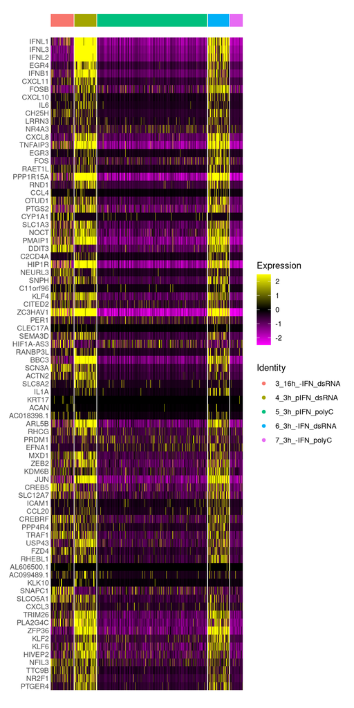

```r
DoHeatmap(a549_cells,
          group.by = "orig.ident",
          features = rigi_only,
          label = FALSE)
```

## RIG-I-only vs NF-κB and viral GO scores

**Panel `rigi_vs_nfkb_virusgo.pdf`.** Per-cell RIG-I-only score versus the NF-κB (top) and viral GO (bottom) scores, coloured by treatment; the Pearson correlation is shown on top of each plot.

*Note:* the current original script writes this PDF with `width=4.0`, but the panel PDF (`figures/2026_August/rigi_vs_nfkb_virusgo.pdf`, 2026-09-24 16:31) is 4.5 x 6 in (the script was edited to 4.0 four minutes later). We keep the 4.5 in width of the panel used in the figure.

```r
p1 <- FeatureScatter(a549_cells,
               feature1 = "rigi_only1",
               feature2 = "NFKB_signature1",
               group.by = "treatment") +
                geom_abline(slope = 1) +
                geom_hline(yintercept = 0,
                           linetype = "dashed") +
                geom_vline(xintercept = 0,
                           linetype = "dashed") +
                NoLegend()

p2 <- FeatureScatter(a549_cells,
               feature1 = "rigi_only1",
               feature2 = "viral_go1",
               group.by = "treatment") +
                geom_abline(slope = 1) +
                geom_hline(yintercept = 0,
                           linetype = "dashed") +
                geom_vline(xintercept = 0,
                           linetype = "dashed") +
                NoLegend()

pdf(file.path(path2figures, "rigi_vs_nfkb_virusgo.pdf"),
    width=4.5, height=6)
p1 / p2
dev.off()
```

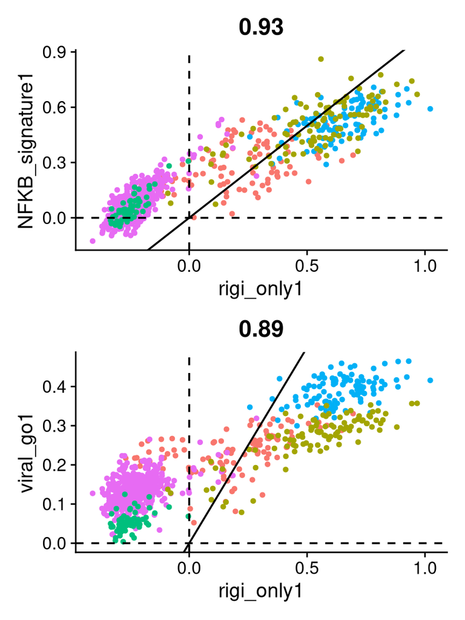

```r
p1 / p2
```

## ROC curves: dsRNA 3 h vs dsRNA 16 h

**Panel `roc_curves_rigi_vs_nfkb_viral_go_test.pdf`.** Using the non-primed dsRNA cells, the scores are used as classifiers of early (3 h, “case”) vs late (16 h, “control”) cells. AUCs of the RIG-I-only, NF-κB and viral GO scores are compared to the RIG-I-only AUC with DeLong tests.

```r
a549_cells_subset <- subset(a549_cells,
                            orig.ident %in%
                                    c("6_3h_-IFN_dsRNA",
                                "3_16h_-IFN_dsRNA"))

# Define case and control groups
a549_cells_subset$case_vs_control <- ifelse(
  grepl("6_3h_-IFN_dsRNA", a549_cells_subset$orig.ident),
  "case",
  "control"
)

# Calculate ROC curves
roc_rigi <- roc(
  response = a549_cells_subset$case_vs_control,
  predictor = a549_cells_subset$rigi_only1,
  levels = c("control", "case"),
  direction = "<"
)

roc_nfkb <- roc(
  response = a549_cells_subset$case_vs_control,
  predictor = a549_cells_subset$NFKB_signature1,
  levels = c("control", "case"),
  direction = "<"
)

roc_viral_go <- roc(
  response = a549_cells_subset$case_vs_control,
  predictor = a549_cells_subset$viral_go1,
  levels = c("control", "case"),
  direction = "<"
)

# DeLong test 1: NF-kB vs RIG-I-only
auc_test_nfkb <- roc.test(
  roc_rigi,
  roc_nfkb,
  method = "delong"
)

# DeLong test 2: Viral GO signature vs RIG-I-only
auc_test_viral_go <- roc.test(
  roc_rigi,
  roc_viral_go,
  method = "delong"
)

## Plotting function: identical code to the original chunk
plot_roc_comparison <- function(){
        # Plot all three ROC curves
        pROC::plot.roc(
          roc_rigi,
          legacy.axes = TRUE,
          lwd = 3,
          main = "ROC curve comparison",
          col = "black"
        )

        pROC::plot.roc(
          roc_nfkb,
          add = TRUE,
          lwd = 3,
          lty = 2,
          col = "blue"
        )

        pROC::plot.roc(
          roc_viral_go,
          add = TRUE,
          lwd = 3,
          lty = 3,
          col = "red"
        )

        # Add legend with AUCs and DeLong tests
        legend(
          "bottomright",
          legend = c(
            paste0(
              "RIG-I-only: AUC = ",
              round(auc(roc_rigi), 3)
            ),
            paste0(
              "NF-kB: AUC = ",
              round(auc(roc_nfkb), 3)
            ),
            paste0(
              "Viral GO: AUC = ",
              round(auc(roc_viral_go), 3)
            ),
            paste0(
              "DeLong NF-kB vs RIG-I: p = ",
              signif(auc_test_nfkb$p.value, 3)
            ),
            paste0(
              "DeLong Viral GO vs RIG-I: p = ",
              signif(auc_test_viral_go$p.value, 3)
            )
          ),
          lwd = c(3, 3, 3, NA, NA),
          lty = c(1, 2, 3, NA, NA),
          col = c("black", "blue", "red", "black", "black"),
          bty = "n"
        )
}

pdf(file.path(path2figures, "roc_curves_rigi_vs_nfkb_viral_go_test.pdf"),
    width=6, height=4.0)
plot_roc_comparison()
dev.off()
```

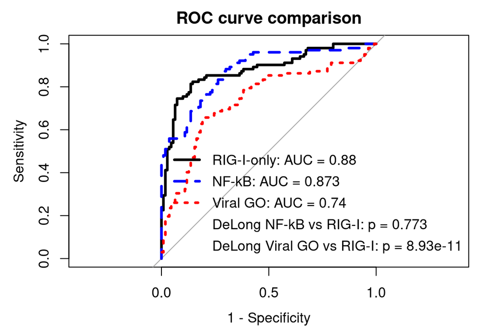

```r
plot_roc_comparison()
```

## ROC curves: dsRNA vs polyC

**Panel `roc_curves_rigi_vs_nfkb.pdf`.** Same comparison, but classifying all dsRNA-electroporated cells (“case”: `3_16h_-IFN_dsRNA`, `4_3h_pIFN_dsRNA`, `6_3h_-IFN_dsRNA`) vs all polyC-electroporated cells (“control”: `5_3h_pIFN_polyC`, `7_3h_-IFN_polyC`).

*Note:* this PDF (2026-09-16) was written by an earlier version of `01_rigi_vs_stat_signatures.Rmd`; in the current version of that script the chunk writing `roc_curves_rigi_vs_nfkb.pdf` is `eval=FALSE` and plots only two curves, whereas the original PDF has three curves (RIG-I-only, NF-κB, viral GO) with the same layout as the 3 h vs 16 h panel. The case/control definition is not stored in the current script; we identified it by testing all sample groupings: dsRNA vs polyC (all cells) reproduces the AUCs (0.98, 0.955, 0.955) and DeLong p-values (1.66e-06, 0.00571) of the original PDF exactly.

```r
a549_cells$case_vs_control <- ifelse(
  grepl("dsRNA", a549_cells$orig.ident),
  "case",
  "control"
)
table(a549_cells$orig.ident, a549_cells$case_vs_control)
```

```
##
##                    case control
##   3_16h_-IFN_dsRNA  110       0
##   4_3h_pIFN_dsRNA   105       0
##   5_3h_pIFN_polyC     0     523
##   6_3h_-IFN_dsRNA   102       0
##   7_3h_-IFN_polyC     0      60
```

```r
# Calculate ROC curves
roc_rigi <- roc(
  response = a549_cells$case_vs_control,
  predictor = a549_cells$rigi_only1,
  levels = c("control", "case"),
  direction = "<"
)

roc_nfkb <- roc(
  response = a549_cells$case_vs_control,
  predictor = a549_cells$NFKB_signature1,
  levels = c("control", "case"),
  direction = "<"
)

roc_viral_go <- roc(
  response = a549_cells$case_vs_control,
  predictor = a549_cells$viral_go1,
  levels = c("control", "case"),
  direction = "<"
)

auc_test_nfkb <- roc.test(roc_rigi, roc_nfkb, method = "delong")
auc_test_viral_go <- roc.test(roc_rigi, roc_viral_go, method = "delong")

pdf(file.path(path2figures, "roc_curves_rigi_vs_nfkb.pdf"),
    width=6, height=4.0)
plot_roc_comparison()
dev.off()
```

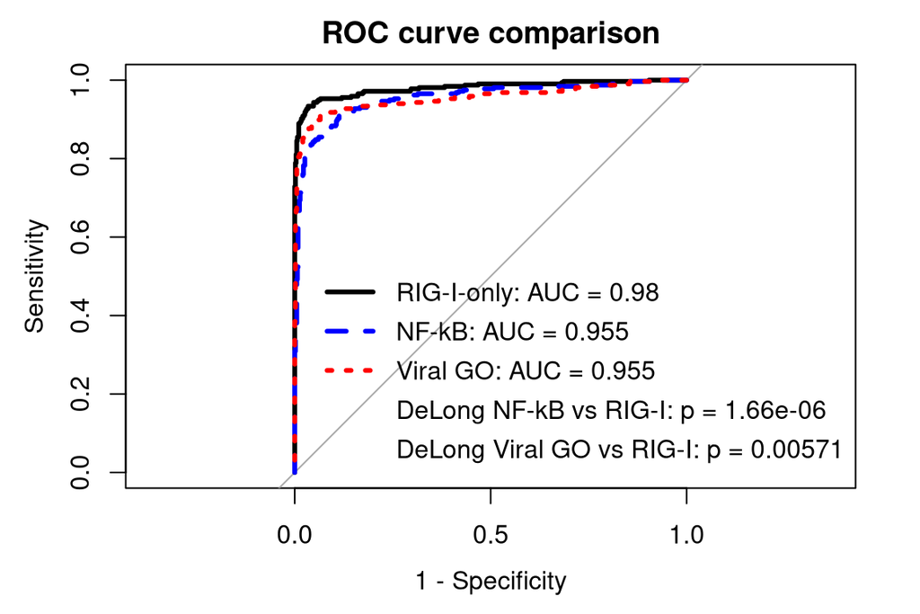

```r
plot_roc_comparison()
```

# Enrichment of the RIG-I-only signature

**Panel `scatterplot_rigi_gsea_general.pdf`.** Over-representation analysis (Enrichr) of the **final** RIG-I-only signature (`path2signs`, IFNB/IFNL genes removed as in the original; the final signature contains none) against general pathway repositories. Each dot is a term: x = -log10(adjusted p-value), y = fraction of the term genes present in the signature; terms with -log10(FDR) > 8.5 are labelled.

```r
signatures <- readRDS(path2signs)
signatures <- lapply(signatures,
                     function(genes){
                             genes[!grepl('IFNB|IFNL', genes)]
})
signatures <- signatures[c(2,1)]
str(signatures)
```

```
## List of 2
##  $ stat_only: chr [1:99] "PNPT1" "TRIM5" "CSF1" "ZNF711" ...
##  $ rigi_only: chr [1:94] "EGR4" "CXCL11" "FOSB" "EGR2" ...
```

*Note on the cache.* The original script (`01_rev_00_signature_similarity.Rmd`) wrote the Enrichr results of the tissue repositories **and** of the general repositories to the same file, `/media/ag-cherrmann/cramirez/interferon_model/analysis/2026_August/enrichr_rigi_tissues_repos.rds`; that file currently holds the tissue results (Azimuth_2023, Jensen_TISSUES, PanglaoDB_Augmented_2021, TISSUES_Curated_2025, Tissue_Protein_Expression_from_ProteomicsDB), so the general results used for the original PDF were not preserved (the cancer-repository results are in `.../2026_August/enrichr_rigi_cancer_repos.rds`, not used here). We therefore re-queried Enrichr once (2026-10-27) with the chunk below (not evaluated) and cached the result in `analysis/supplementary_figure_01/enrichr_rigi_general_repos.rds`. The re-query reproduces the original panel (e.g. MSigDB Hallmark “TNF-alpha Signaling via NF-kB”, 30/200 genes).

```r
setEnrichrSite("Enrichr")

general_repos <- c("WikiPathway_2023_Human",
                  "MSigDB_Hallmark_2020",
                  "KEGG_2026",
                  "GO_Biological_Process_2025")

enrich_general_results <- enrichr(
            genes = signatures$rigi_only,
            databases = general_repos
        )

saveRDS(enrich_general_results,
        file.path(path2analysis, "enrichr_rigi_general_repos.rds"),
        compress = TRUE)
```

```r
enrich_general_results <- readRDS(file.path(path2analysis, "enrichr_rigi_general_repos.rds"))

all_general_results <- bind_rows(
    lapply(names(enrich_general_results), function(db) {

        res <- enrich_general_results[[db]]

        if (is.null(res))
            return(NULL)

        res %>%
            mutate(Database = db)
    })
)

all_general_results <- all_general_results %>%
  tidyr::separate(Overlap,
           into = c("Overlap_n", "Overlap_total"),
           sep = "/",
           convert = TRUE) %>%
  mutate(
    Overlap_fraction = Overlap_n / Overlap_total
  )


scatterplot_gsea_general <- all_general_results %>%
    mutate(
        logFDR = -log10(`Adjusted.P.value`),
        label = ifelse(logFDR > 8.5, Term, NA)
    ) %>%
    ggplot(aes(x = logFDR,
               y = Overlap_fraction,
               colour = Database)) +
    geom_point() +
    geom_text_repel(
        aes(label = label),
        force = 0.5,
        max.overlaps = Inf
    ) +
    theme_classic() +
    theme(axis.text = element_text(size = 20),
          axis.title = element_text(size = 24)) +
        labs(x="-log10(Adjusted.P.value)",
             y="Overlap fraction",
             title = "General datasets")


pdf(file.path(path2figures, "scatterplot_rigi_gsea_general.pdf"),
    width=8, height=6)
scatterplot_gsea_general
dev.off()
```

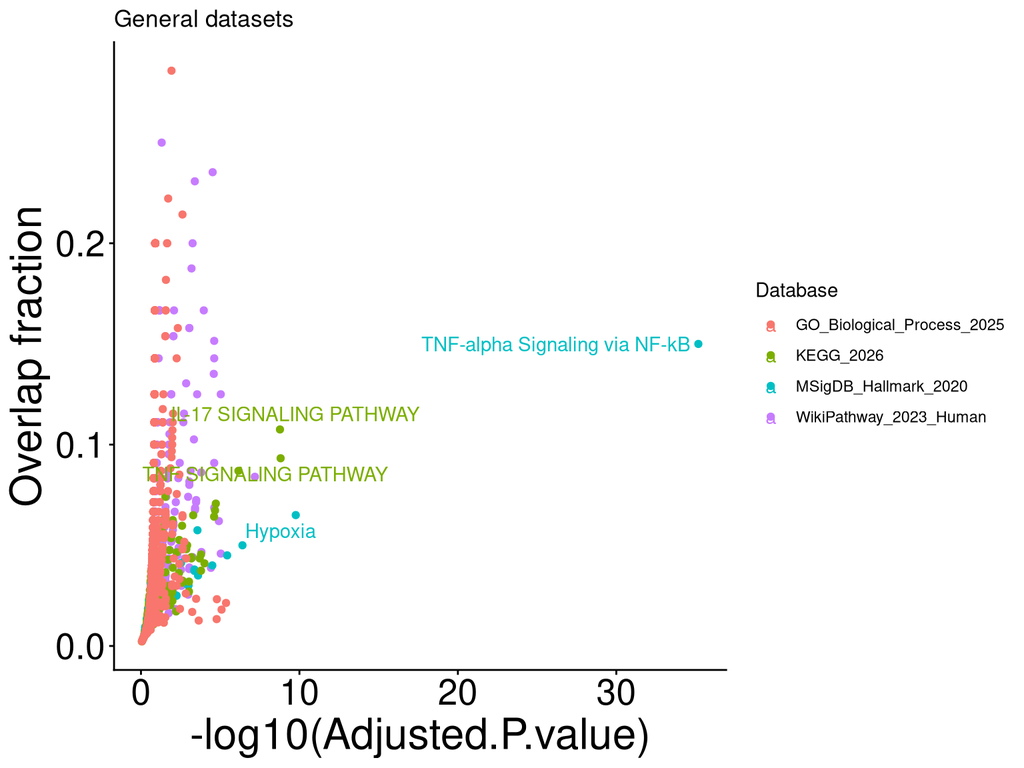

```r
scatterplot_gsea_general
```